# Iteration

Jana Lee

10/24/2019

# Lecture: Writing Functions

```r
x = rnorm(n = 30, mean = 4, sd = 2.3)
x_again = rnorm(n = 30, mean = 6, sd = .3)

y = rnorm(n = 30, mean = 24, sd = 2.3)
(x - mean(x)) / sd(x)
```

```
##  [1]  0.58561815 -0.84519326 -1.37284575 -1.04949045  0.73304439
##  [6]  0.18213650 -1.55560080 -0.36279229 -1.13376808  1.02001963
## [11]  0.19152979 -0.41179768  1.54723776  2.61692862 -0.43717924
## [16]  1.37763238 -1.09886038  0.85940458 -0.20853366  0.37519659
## [21]  0.83797266  0.30056357  0.42474825  1.09127680 -0.04659055
## [26] -1.11815484 -0.19673709 -0.21727285 -1.32506622 -0.76342652
```

```r
(x_again - mean(x_again)) / sd(x_again)
```

```
##  [1]  0.29687075 -1.29149145 -1.10797431 -0.95890053  0.17256985
##  [6] -1.94273780  1.19948958 -1.05490929  1.61165928  0.29187575
## [11] -0.06226848 -0.25110575 -1.36658873  0.55626299  0.62667429
## [16]  0.51868398  0.20021601  2.02542531 -0.02143394 -1.08947808
## [21] -0.19305497 -0.56729029  0.62970112  1.49878368  1.00268435
## [26] -0.38914393 -0.28586545  1.50719261 -0.55367105 -1.00217548
```

But this is not great bc room for mistakes. Instead, we write a function.

```r
z_score = function(x_arg) {

  if (!is.numeric(x_arg)) {
    stop("x should be numeric")
  } else if (length(x_arg) < 3) {
    stop("x should be longer than 3")
  }

  (x_arg - mean(x_arg)) / sd(x_arg)

}

# Now, test the function:
z_score(x = x_again)
```

```
##  [1]  0.29687075 -1.29149145 -1.10797431 -0.95890053  0.17256985
##  [6] -1.94273780  1.19948958 -1.05490929  1.61165928  0.29187575
## [11] -0.06226848 -0.25110575 -1.36658873  0.55626299  0.62667429
## [16]  0.51868398  0.20021601  2.02542531 -0.02143394 -1.08947808
## [21] -0.19305497 -0.56729029  0.62970112  1.49878368  1.00268435
## [26] -0.38914393 -0.28586545  1.50719261 -0.55367105 -1.00217548
```

```r
#Any argument we put in here, we will get the function of z_score.
```

```r
z_score(x_arg = y)
```

```
##  [1]  0.6226359 -1.2407396  1.1984622 -0.3799469 -1.0319247  0.6151186
##  [7]  1.5133904 -1.9084686 -0.6619521  0.5688801  0.7518716  0.9879127
## [13] -0.4294572  0.4276806  0.2200516 -1.5583620 -0.2152530 -0.3036727
## [19]  0.3132781 -0.1943515  0.9156920 -1.5576554  1.3693425  1.2300734
## [25]  1.4055191 -0.4072786  0.1112725 -1.8003869 -0.7751813  0.2134491
```

```r
z_score(x_arg = 3)
```

```
## Error in z_score(x_arg = 3): x should be longer than 3
```

```r
z_score(x_arg = "my name is jeff")
```

```
## Error in z_score(x_arg = "my name is jeff"): x should be numeric
```

```r
z_score(x_arg = c(TRUE, TRUE, FALSE, TRUE))
```

```
## Error in z_score(x_arg = c(TRUE, TRUE, FALSE, TRUE)): x should be numeric
```

```r
z_score(x_arg = iris)
```

```
## Error in z_score(x_arg = iris): x should be numeric
```

```r
mean_and_sd = function(input_x) {

  if (!is.numeric(input_x)) {
    stop("x should be numeric")
  } else if (length(input_x) < 3) {
    stop("x should be longer than 3")
  }

  list(
    mean_input = mean(input_x),
    sd_input = sd(input_x),
    z_score = (input_x - mean(input_x)) / sd(input_x)
  )

}

mean_and_sd(input_x = y)
```

```
## $mean_input
## [1] 24.27495
##
## $sd_input
## [1] 2.52192
##
## $z_score
##  [1]  0.6226359 -1.2407396  1.1984622 -0.3799469 -1.0319247  0.6151186
##  [7]  1.5133904 -1.9084686 -0.6619521  0.5688801  0.7518716  0.9879127
## [13] -0.4294572  0.4276806  0.2200516 -1.5583620 -0.2152530 -0.3036727
## [19]  0.3132781 -0.1943515  0.9156920 -1.5576554  1.3693425  1.2300734
## [25]  1.4055191 -0.4072786  0.1112725 -1.8003869 -0.7751813  0.2134491
```

**Lists** = allow you any number of things you want to combine in 1 output structure.

## Multiple Outputs

```r
sim_data = tibble(
  x = rnorm(30, mean = 1, sd = 1),
  y = 2 + 3 * x + rnorm(30, 0, 1)
)

ls_fit = lm(y ~ x, data = sim_data)

beta0_hat = coef(ls_fit)[1]
beta1_hat = coef(ls_fit)[2]
```

```r
sim_regression = function(n, beta0 = 2, beta1 = 3) {

  sim_data = tibble(
    x = rnorm(n, mean = 1, sd = 1),
    y = beta0 + beta1 * x + rnorm(n, 0, 1)
  )

  ls_fit = lm(y ~ x, data = sim_data)

  tibble(
    beta0_hat = coef(ls_fit)[1],
    beta1_hat = coef(ls_fit)[2]
  )
}

sim_regression(n = 3000, beta0 = 17, beta1 = -3)
```

```
## # A tibble: 1 x 2
##   beta0_hat beta1_hat
##       <dbl>     <dbl>
## 1      17.0     -3.00
```

## Scraping on Napolean Dynamite Amazon Example

Going to try to write a function for this, if we wanted to scrape multiple pages!

```r
url = "https://www.amazon.com/product-reviews/B00005JNBQ/ref=cm_cr_arp_d_viewopt_rvwer?ie=UTF8&reviewerType=avp_only_reviews&sortBy=recent&pageNumber=1"

dynamite_html = read_html(url)

review_titles = dynamite_html %>%
  html_nodes("#cm_cr-review_list .review-title") %>%
  html_text()

review_stars = dynamite_html %>%
  html_nodes("#cm_cr-review_list .review-rating") %>%
  html_text()

review_text = dynamite_html %>%
    html_nodes(".review-data:nth-child(4)") %>%
    html_text()

reviews = tibble(
  title = review_titles,
  stars = review_stars,
  text = review_text
)
```

```r
read_page_reviews = function(page_url) {
  dynamite_html = read_html(url)

review_titles = dynamite_html %>%
  html_nodes("#cm_cr-review_list .review-title") %>%
  html_text()

review_stars = dynamite_html %>%
  html_nodes("#cm_cr-review_list .review-rating") %>%
  html_text()

review_text = dynamite_html %>%
    html_nodes(".review-data:nth-child(4)") %>%
    html_text()

reviews = tibble(
  title = review_titles,
  stars = review_stars,
  text = review_text)

  reviews
}
```

Option + shift + click = can have multiple cursors

```r
read_page_reviews("https://www.amazon.com/product-reviews/B00005JNBQ/ref=cm_cr_arp_d_viewopt_rvwer?ie=UTF8&reviewerType=avp_only_reviews&sortBy=recent&pageNumber=1")
```

```
## # A tibble: 10 x 3
##    title                           stars         text
##    <chr>                           <chr>         <chr>
##  1 "Gotta watch it!\n            " 5.0 out of 5… Format: Prime VideoVerifi…
##  2 "Great movie\n            "     5.0 out of 5… Format: Blu-rayVerified P…
##  3 "Duh\n            "             5.0 out of 5… Format: Prime VideoVerifi…
##  4 "Great video\n            "     5.0 out of 5… Format: DVDVerified Purch…
##  5 "Give me some of your tots\n  … 5.0 out of 5… Format: Prime VideoVerifi…
##  6 "Nostalgic\n            "       5.0 out of 5… Format: Prime VideoVerifi…
##  7 "Make you giggle type movie\n … 5.0 out of 5… Format: Blu-rayVerified P…
##  8 "This movie is so stupid.\n   … 5.0 out of 5… Format: Prime VideoVerifi…
##  9 "Hilarious\n            "       5.0 out of 5… Format: Prime VideoVerifi…
## 10 "Waste of money\n            "  1.0 out of 5… Format: Prime VideoVerifi…
```

```r
read_page_reviews("https://www.amazon.com/product-reviews/B00005JNBQ/ref=cm_cr_arp_d_viewopt_rvwer?ie=UTF8&reviewerType=avp_only_reviews&sortBy=recent&pageNumber=2")
```

```
## # A tibble: 10 x 3
##    title                           stars         text
##    <chr>                           <chr>         <chr>
##  1 "Gotta watch it!\n            " 5.0 out of 5… Format: Prime VideoVerifi…
##  2 "Great movie\n            "     5.0 out of 5… Format: Blu-rayVerified P…
##  3 "Duh\n            "             5.0 out of 5… Format: Prime VideoVerifi…
##  4 "Great video\n            "     5.0 out of 5… Format: DVDVerified Purch…
##  5 "Give me some of your tots\n  … 5.0 out of 5… Format: Prime VideoVerifi…
##  6 "Nostalgic\n            "       5.0 out of 5… Format: Prime VideoVerifi…
##  7 "Make you giggle type movie\n … 5.0 out of 5… Format: Blu-rayVerified P…
##  8 "This movie is so stupid.\n   … 5.0 out of 5… Format: Prime VideoVerifi…
##  9 "Hilarious\n            "       5.0 out of 5… Format: Prime VideoVerifi…
## 10 "Waste of money\n            "  1.0 out of 5… Format: Prime VideoVerifi…
```

```r
read_page_reviews("https://www.amazon.com/product-reviews/B00005JNBQ/ref=cm_cr_arp_d_viewopt_rvwer?ie=UTF8&reviewerType=avp_only_reviews&sortBy=recent&pageNumber=3")
```

```
## # A tibble: 10 x 3
##    title                           stars         text
##    <chr>                           <chr>         <chr>
##  1 "Gotta watch it!\n            " 5.0 out of 5… Format: Prime VideoVerifi…
##  2 "Great movie\n            "     5.0 out of 5… Format: Blu-rayVerified P…
##  3 "Duh\n            "             5.0 out of 5… Format: Prime VideoVerifi…
##  4 "Great video\n            "     5.0 out of 5… Format: DVDVerified Purch…
##  5 "Give me some of your tots\n  … 5.0 out of 5… Format: Prime VideoVerifi…
##  6 "Nostalgic\n            "       5.0 out of 5… Format: Prime VideoVerifi…
##  7 "Make you giggle type movie\n … 5.0 out of 5… Format: Blu-rayVerified P…
##  8 "This movie is so stupid.\n   … 5.0 out of 5… Format: Prime VideoVerifi…
##  9 "Hilarious\n            "       5.0 out of 5… Format: Prime VideoVerifi…
## 10 "Waste of money\n            "  1.0 out of 5… Format: Prime VideoVerifi…
```

```r
read_page_reviews("https://www.amazon.com/product-reviews/B00005JNBQ/ref=cm_cr_arp_d_viewopt_rvwer?ie=UTF8&reviewerType=avp_only_reviews&sortBy=recent&pageNumber=4")
```

```
## # A tibble: 10 x 3
##    title                           stars         text
##    <chr>                           <chr>         <chr>
##  1 "Gotta watch it!\n            " 5.0 out of 5… Format: Prime VideoVerifi…
##  2 "Great movie\n            "     5.0 out of 5… Format: Blu-rayVerified P…
##  3 "Duh\n            "             5.0 out of 5… Format: Prime VideoVerifi…
##  4 "Great video\n            "     5.0 out of 5… Format: DVDVerified Purch…
##  5 "Give me some of your tots\n  … 5.0 out of 5… Format: Prime VideoVerifi…
##  6 "Nostalgic\n            "       5.0 out of 5… Format: Prime VideoVerifi…
##  7 "Make you giggle type movie\n … 5.0 out of 5… Format: Blu-rayVerified P…
##  8 "This movie is so stupid.\n   … 5.0 out of 5… Format: Prime VideoVerifi…
##  9 "Hilarious\n            "       5.0 out of 5… Format: Prime VideoVerifi…
## 10 "Waste of money\n            "  1.0 out of 5… Format: Prime VideoVerifi…
```

# Lecture: Iteration and List Columns

Why iterate? - need to write the same basic thing a lot

## for loops

loops - an output object, a sequence to iterate over, the loop body, and an input object. Going to use purr package

- map function - prodces the same result as the for loop, but emphasizes the input and function and reduces the amount of overhead

## Lists

```r
library(tidyverse)

set.seed(1)
```

### Making a list

```r
l = list(vec_numeric = 5:8,
         mat         = matrix(1:8, 2, 4),
         vec_logical = c(TRUE, FALSE),
         summary     = summary(rnorm(1000)))
l
```

```
## $vec_numeric
## [1] 5 6 7 8
##
## $mat
##      [,1] [,2] [,3] [,4]
## [1,]    1    3    5    7
## [2,]    2    4    6    8
##
## $vec_logical
## [1]  TRUE FALSE
##
## $summary
##     Min.  1st Qu.   Median     Mean  3rd Qu.     Max.
## -3.00805 -0.69737 -0.03532 -0.01165  0.68843  3.81028
```

```r
mean(l$vec_numeric)
```

```
## [1] 6.5
```

Setting up for for loop

```r
df = list(
  a = rnorm(20, 3, 1),
  b = rnorm(20, 0, 5),
  c = rnorm(20, 10, .2),
  d = rnorm(20, -3, 1)
)

df$a
```

```
##  [1] 4.134965 4.111932 2.129222 3.210732 3.069396 1.337351 3.810840
##  [8] 1.087654 1.753247 3.998154 2.459127 2.783624 1.378063 1.549036
## [15] 3.350910 2.825453 2.408572 1.665973 1.902701 5.036104
```

```r
df[[2]]
```

```
##  [1] -1.63244797  3.87002606  3.92503200  3.81623040  1.47404380
##  [6] -6.26177962 -5.04751876  3.75695597 -6.54176756  2.63770049
## [11] -2.66769787 -1.99188007 -3.94784725 -1.15070568  4.38592421
## [16]  2.26866589 -1.16232074  4.35002762  8.28001867 -0.03184464
```

```r
is.list(df)
```

```
## [1] TRUE
```

```r
mean_and_sd = function(x) {

  if (!is.numeric(x)) {
    stop("Argument x should be numeric")
  } else if (length(x) == 1) {
    stop("Cannot be computed for length 1 vectors")
  }

  mean_x = mean(x)
  sd_x = sd(x)

  tibble(
    mean = mean_x,
    sd = sd_x
  )
}
```

## for loops

Taking mean and sd for every list is not efficient. Using for loops will make it more efficient.

```r
output = vector("list", length = 4)

for (i in 1:4) {
  output[[i]] = mean_and_sd(df[[i]])
}

output = map(df, mean_and_sd)
# this map makes it easier to read, can map across each element

output_median = map(df, median)

output_summary = map(df, summary)

output = map_df(.x = df, ~ mean_and_sd(.x))
```

### Revisiting Napolean dynamite Example

```r
library(rvest)

read_page_reviews = function(url) {

  h = read_html(url)

  title = h %>%
    html_nodes("#cm_cr-review_list .review-title") %>%
    html_text()

  stars = h %>%
    html_nodes("#cm_cr-review_list .review-rating") %>%
    html_text() %>%
    str_extract("\\d") %>%
    as.numeric()

  text = h %>%
    html_nodes(".review-data:nth-child(5)") %>%
    html_text()

  data_frame(title, stars, text)
}
```

```r
url_base = "https://www.amazon.com/product-reviews/B00005JNBQ/ref=cm_cr_arp_d_viewopt_rvwer?ie=UTF8&reviewerType=avp_only_reviews&sortBy=recent&pageNumber="
vec_urls = str_c(url_base, 1:5)

read_page_reviews(vec_urls[[1]])
```

```
## # A tibble: 10 x 3
##    title                     stars text
##    <chr>                     <dbl> <chr>
##  1 "Gotta watch it!\n      …     5 "Super fun cult film. A must-see! Funni…
##  2 "Great movie\n          …     5 "Love this movie.\n            "
##  3 "Duh\n            "           5 "Best movie ever\n            "
##  4 "Great video\n          …     5 "Product as described.  Great transacti…
##  5 "Give me some of your to…     5 "This movie will always be my favorite …
##  6 "Nostalgic\n            "     5 "One of the best nostalgic movies of my…
##  7 "Make you giggle type mo…     5 "I love, love, love this movie.  It mak…
##  8 "This movie is so stupid…     5 "No, really.  It's so stupid.  Your IQ …
##  9 "Hilarious\n            "     5 "Hilarious\n            "
## 10 "Waste of money\n       …     1 "Terrible movie! Please don’t waste you…
```

We don’t want to keep repetitively writing the same code. Use for loop and map statement.

```r
output = vector("list", length = 5)

for (i in 1:5) {
  output[[i]] = read_page_reviews(vec_urls[[i]])
}

output = map(vec_urls, read_page_reviews)
```

## list columns

```r
weather =
  rnoaa::meteo_pull_monitors(
    c("USW00094728", "USC00519397", "USS0023B17S"),
    var = c("PRCP", "TMIN", "TMAX"),
    date_min = "2016-01-01",
    date_max = "2016-12-31") %>%
  mutate(
    name = recode(id, USW00094728 = "CentralPark_NY",
                      USC00519397 = "Waikiki_HA",
                      USS0023B17S = "Waterhole_WA"),
    tmin = tmin / 10,
    tmax = tmax / 10) %>%
  select(name, id, everything())
```

```
## file path:          /Users/jmlee/Library/Caches/rnoaa/ghcnd/USW00094728.dly
```

```
## file last updated:  2019-09-26 10:26:02
```

```
## file min/max dates: 1869-01-01 / 2019-09-30
```

```
## file path:          /Users/jmlee/Library/Caches/rnoaa/ghcnd/USC00519397.dly
```

```
## file last updated:  2019-09-26 10:26:18
```

```
## file min/max dates: 1965-01-01 / 2019-09-30
```

```
## file path:          /Users/jmlee/Library/Caches/rnoaa/ghcnd/USS0023B17S.dly
```

```
## file last updated:  2019-09-26 10:26:23
```

```
## file min/max dates: 1999-09-01 / 2019-09-30
```

### nest function

- nest is used by specifying a column range to collapse within remaining variable values

```r
weather_nest =
  nest(weather, data = date:tmin)

weather_nest
```

```
## # A tibble: 3 x 3
##   name           id                    data
##   <chr>          <chr>       <list<df[,4]>>
## 1 CentralPark_NY USW00094728      [366 × 4]
## 2 Waikiki_HA     USC00519397      [366 × 4]
## 3 Waterhole_WA   USS0023B17S      [366 × 4]
```

Pulling out a list from this

```r
weather_nest %>%  pull(name)
```

```
## [1] "CentralPark_NY" "Waikiki_HA"     "Waterhole_WA"
```

```r
weather_nest %>%  pull(data)
```

```
## <list_of<
##   tbl_df<
##     date: date
##     prcp: double
##     tmax: double
##     tmin: double
##   >
## >[3]>
## [[1]]
## # A tibble: 366 x 4
##    date        prcp  tmax  tmin
##    <date>     <dbl> <dbl> <dbl>
##  1 2016-01-01     0   5.6   1.1
##  2 2016-01-02     0   4.4   0
##  3 2016-01-03     0   7.2   1.7
##  4 2016-01-04     0   2.2  -9.9
##  5 2016-01-05     0  -1.6 -11.6
##  6 2016-01-06     0   5    -3.8
##  7 2016-01-07     0   7.8  -0.5
##  8 2016-01-08     0   7.8  -0.5
##  9 2016-01-09     0   8.3   4.4
## 10 2016-01-10   457  15     4.4
## # … with 356 more rows
##
## [[2]]
## # A tibble: 366 x 4
##    date        prcp  tmax  tmin
##    <date>     <dbl> <dbl> <dbl>
##  1 2016-01-01     0  29.4  16.7
##  2 2016-01-02     0  28.3  16.7
##  3 2016-01-03     0  28.3  16.7
##  4 2016-01-04     0  28.3  16.1
##  5 2016-01-05     0  27.2  16.7
##  6 2016-01-06     0  27.2  20
##  7 2016-01-07    46  27.8  18.3
##  8 2016-01-08     3  28.3  17.8
##  9 2016-01-09     8  27.8  19.4
## 10 2016-01-10     3  28.3  18.3
## # … with 356 more rows
##
## [[3]]
## # A tibble: 366 x 4
##    date        prcp  tmax  tmin
##    <date>     <dbl> <dbl> <dbl>
##  1 2016-01-01     0   1.7  -5.9
##  2 2016-01-02    25  -0.1  -6
##  3 2016-01-03     0  -5   -10
##  4 2016-01-04    25   0.3  -9.8
##  5 2016-01-05    25   1.9  -1.8
##  6 2016-01-06    25   1.4  -2.6
##  7 2016-01-07     0   1.4  -3.9
##  8 2016-01-08     0   1.1  -4
##  9 2016-01-09     0   1.4  -4.5
## 10 2016-01-10     0   2.3  -3.8
## # … with 356 more rows
```

```r
weather_nest$data[[1]]
```

```
## # A tibble: 366 x 4
##    date        prcp  tmax  tmin
##    <date>     <dbl> <dbl> <dbl>
##  1 2016-01-01     0   5.6   1.1
##  2 2016-01-02     0   4.4   0
##  3 2016-01-03     0   7.2   1.7
##  4 2016-01-04     0   2.2  -9.9
##  5 2016-01-05     0  -1.6 -11.6
##  6 2016-01-06     0   5    -3.8
##  7 2016-01-07     0   7.8  -0.5
##  8 2016-01-08     0   7.8  -0.5
##  9 2016-01-09     0   8.3   4.4
## 10 2016-01-10   457  15     4.4
## # … with 356 more rows
```

We can also unnest

```r
weather_nest %>%
  unnest()
```

```
## # A tibble: 1,098 x 6
##    name           id          date        prcp  tmax  tmin
##    <chr>          <chr>       <date>     <dbl> <dbl> <dbl>
##  1 CentralPark_NY USW00094728 2016-01-01     0   5.6   1.1
##  2 CentralPark_NY USW00094728 2016-01-02     0   4.4   0
##  3 CentralPark_NY USW00094728 2016-01-03     0   7.2   1.7
##  4 CentralPark_NY USW00094728 2016-01-04     0   2.2  -9.9
##  5 CentralPark_NY USW00094728 2016-01-05     0  -1.6 -11.6
##  6 CentralPark_NY USW00094728 2016-01-06     0   5    -3.8
##  7 CentralPark_NY USW00094728 2016-01-07     0   7.8  -0.5
##  8 CentralPark_NY USW00094728 2016-01-08     0   7.8  -0.5
##  9 CentralPark_NY USW00094728 2016-01-09     0   8.3   4.4
## 10 CentralPark_NY USW00094728 2016-01-10   457  15     4.4
## # … with 1,088 more rows
```

### Operations on list columns

```r
central_park_df = weather_nest$data[[1]]

lm(tmax ~ tmin, data = central_park_df)
```

```
##
## Call:
## lm(formula = tmax ~ tmin, data = central_park_df)
##
## Coefficients:
## (Intercept)         tmin
##       7.779        1.045
```

```r
lm(tmax ~ tmin, data = weather_nest$data[[1]])
```

```
##
## Call:
## lm(formula = tmax ~ tmin, data = weather_nest$data[[1]])
##
## Coefficients:
## (Intercept)         tmin
##       7.779        1.045
```

```r
lm(tmax ~ tmin, data = weather_nest$data[[2]])
```

```
##
## Call:
## lm(formula = tmax ~ tmin, data = weather_nest$data[[2]])
##
## Coefficients:
## (Intercept)         tmin
##      22.489        0.326
```

```r
lm(tmax ~ tmin, data = weather_nest$data[[3]])
```

```
##
## Call:
## lm(formula = tmax ~ tmin, data = weather_nest$data[[3]])
##
## Coefficients:
## (Intercept)         tmin
##       6.851        1.245
```

Doing a loop:

```r
output = vector("list", length = 3)

for (i in 1:3) {
  output[[i]] = lm(tmax ~ tmin, weather_nest$data[[i]])

}
```

Try to turn this into a map statement

```r
weather_lm = function(df) {

  lm(tmax ~ tmin, data = df)
}
```

Try to map:

```r
for (i in 1:3) {

  output[[i]] = weather_lm(weather_nest$data[[i]])
}

output = map(weather_nest$data, weather_lm)
```

How do we knit this into a readable format? We will revisit in a day or two…

### Using mutate to add columns

```r
weather_nest %>%
  mutate(lin_models = map(data, weather_lm)) %>%
  select(-data) %>%
  filter(name != "CentralPark_NY")
```

```
## # A tibble: 2 x 3
##   name         id          lin_models
##   <chr>        <chr>       <list>
## 1 Waikiki_HA   USC00519397 <lm>
## 2 Waterhole_WA USS0023B17S <lm>
```

When we run this, we see name and ID, but we also see lin_models! Taken original dataset and created separate linear models inside of this.

### Napolean example again

```r
napoleon =
  tibble(
    page = 1:5,
    urls = str_c(url_base, page)
  ) %>%
  mutate(
    reviews = map(urls, read_page_reviews)
  ) %>%
  unnest(reviews) %>%
  select(-urls)

view(napoleon)
```

# Lecture: Simulation

Reusing function from a couple of lectures ago:

```r
set.seed(1)

sim_regression = function(n, beta0 = 2, beta1 = 3) {

  sim_data = tibble(
    x = rnorm(n, mean = 1, sd = 1),
    y = beta0 + beta1 * x + rnorm(n, 0, 1)
  )

  ls_fit = lm(y ~ x, data = sim_data)

  tibble(
    beta0_hat = coef(ls_fit)[1],
    beta1_hat = coef(ls_fit)[2]
  )
}
```

## rerun using a for loop

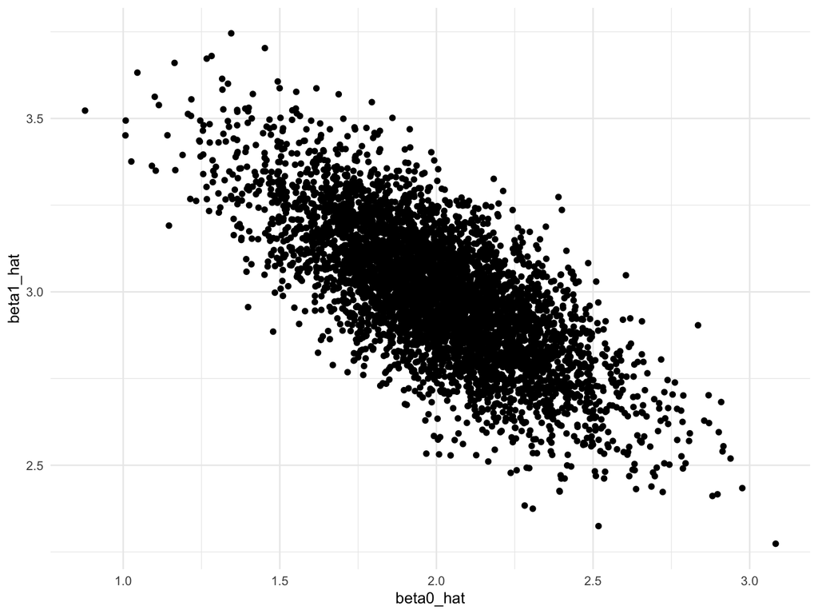

```r
output = vector("list", length = 5000)

for (i in 1:5000) {
  output[[i]] = sim_regression(n = 30)
}

bind_rows(output) %>%
  ggplot(aes(x = beta0_hat, y = beta1_hat)) +
  geom_point()
```

## Rerun simulation using “purr”

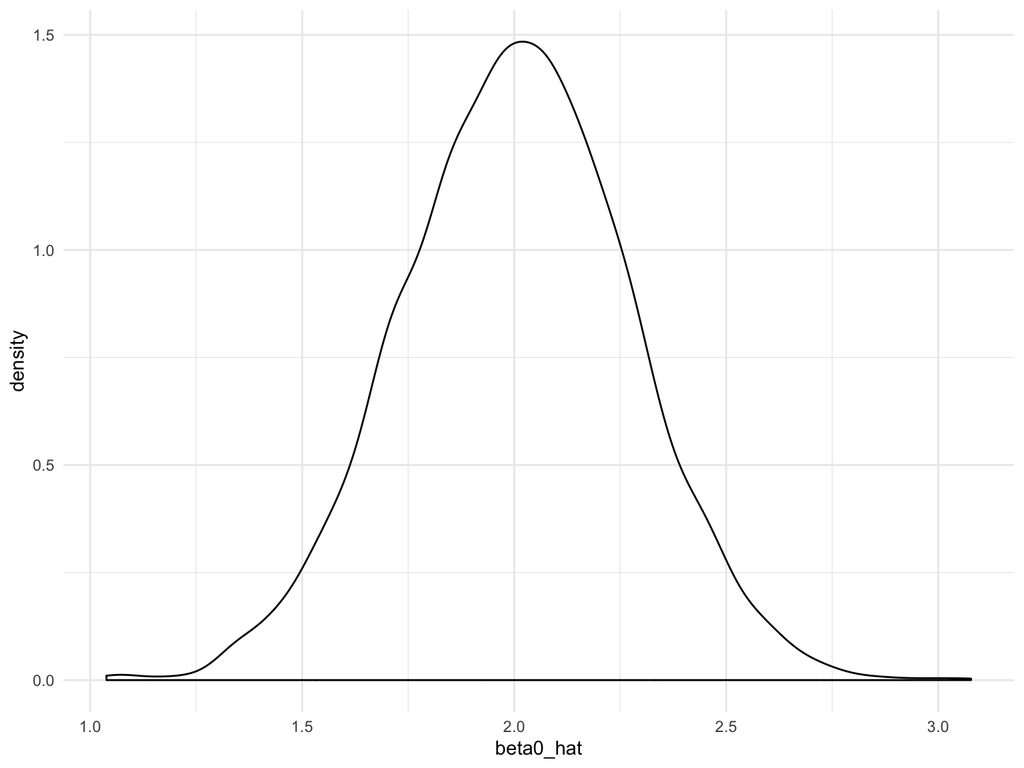

```r
output = rerun(5000, sim_regression(n = 30))

bind_rows(output) %>%
  ggplot(aes(x = beta0_hat)) + geom_density()
```